# MATH 311 Final Project

Ben Czekanski & Michael Czekanski

5/18/2018

# Introduction

At 10:35 am on December 17, 1903, Orville Wright was the first human to experience mechanical flight. As Orville reached this magical high that millions of people have experienced since, Wilbur was the first human to experience the terrible low that is a flight cancellation. The brothers flipped a coin to choose who got to fly first that day, but in our paper we try to do better than chance in predicting flight cancellations. We use daily atmospheric data from Boston, Atlanta, Detroit, and New York City to predict $\textit{whether}$ (weather, geddit?) flights leaving Boston will be cancelled.

# Methods

## Data

Our flight data contains 1112894 flights leaving Boston’s Logan Airport from 2003-09-01 to 2012-12-31. There are 31345 total cancellations. The most cancellations on a single day is 324 cancellations on 2005-01-23. For each day in this period we have the weather in Boston, New York City, Detroit, and Atlanta. These weather in these major hubs gives us a sense if there are storms around the country that might affect flights in Boston even if there is nice weather in Massachusetts. Additionally, we incorporate lagged weather variables to account for storms that might move from one of these cities into Boston and affect flights in this way.

The variables that we have are:

STATION, NAME, DATE, AWND, FMTM, PGTM, PRCP, SNOW, SNWD, TAVG, TMAX, TMIN, WESD, WSF2, WSF5, WT01, WT02, WT03, WT04, WT05, WT06, WT07, WT08, WT09, WT10, WT11, WT13, WT14, WT15, WT16, WT17, WT18, WT19, WT21, WT22, WV03, SNOW_lag1, PRCP_lag1, TMIN_lag1, SNWD_lag1, TMAX_lag1, SNOW_lag2, PRCP_lag2, TMIN_lag2, SNWD_lag2, TMAX_lag2, SNOW_lag3, PRCP_lag3, TMIN_lag3, SNWD_lag3, TMAX_lag3, PRCP.TMIN.l32, PRCP.TMAX.l32, STATION.atl, NAME.atl, AWND.atl, FMTM.atl, PGTM.atl, PRCP.atl, SNOW.atl, SNWD.atl, TAVG.atl, TMAX.atl, TMIN.atl, WESD.atl, WSF2.atl, WSF5.atl, WT01.atl, WT02.atl, WT03.atl, WT04.atl, WT05.atl, WT06.atl, WT07.atl, WT08.atl, WT09.atl, WT10.atl, WT11.atl, WT13.atl, WT14.atl, WT15.atl, WT16.atl, WT17.atl, WT18.atl, WT19.atl, WT21.atl, WT22.atl, WV03.atl, SNOW_lag1.atl, PRCP_lag1.atl, TMIN_lag1.atl, SNWD_lag1.atl, TMAX_lag1.atl, SNOW_lag2.atl, PRCP_lag2.atl, TMIN_lag2.atl, SNWD_lag2.atl, TMAX_lag2.atl, SNOW_lag3.atl, PRCP_lag3.atl, TMIN_lag3.atl, SNWD_lag3.atl, TMAX_lag3.atl, PRCP.TMIN.l32.atl, PRCP.TMAX.l32.atl, STATION.det, NAME.det, AWND.det, FMTM.det, PGTM.det, PRCP.det, SNOW.det, SNWD.det, TAVG.det, TMAX.det, TMIN.det, WESD.det, WSF2.det, WSF5.det, WT01.det, WT02.det, WT03.det, WT04.det, WT05.det, WT06.det, WT07.det, WT08.det, WT09.det, WT10.det, WT11.det, WT13.det, WT14.det, WT15.det, WT16.det, WT17.det, WT18.det, WT19.det, WT21.det, WT22.det, WV03.det, SNOW_lag1.det, PRCP_lag1.det, TMIN_lag1.det, SNWD_lag1.det, TMAX_lag1.det, SNOW_lag2.det, PRCP_lag2.det, TMIN_lag2.det, SNWD_lag2.det, TMAX_lag2.det, SNOW_lag3.det, PRCP_lag3.det, TMIN_lag3.det, SNWD_lag3.det, TMAX_lag3.det, PRCP.TMIN.l32.det, PRCP.TMAX.l32.det, STATION.nyc, NAME.nyc, AWND.nyc, FMTM.nyc, PGTM.nyc, PRCP.nyc, SNOW.nyc, SNWD.nyc, TAVG.nyc, TMAX.nyc, TMIN.nyc, WESD.nyc, WSF2.nyc, WSF5.nyc, WT01.nyc, WT02.nyc, WT03.nyc, WT04.nyc, WT05.nyc, WT06.nyc, WT07.nyc, WT08.nyc, WT09.nyc, WT10.nyc, WT11.nyc, WT13.nyc, WT14.nyc, WT15.nyc, WT16.nyc, WT17.nyc, WT18.nyc, WT19.nyc, WT21.nyc, WT22.nyc, WV03.nyc, SNOW_lag1.nyc, PRCP_lag1.nyc, TMIN_lag1.nyc, SNWD_lag1.nyc, TMAX_lag1.nyc, SNOW_lag2.nyc, PRCP_lag2.nyc, TMIN_lag2.nyc, SNWD_lag2.nyc, TMAX_lag2.nyc, SNOW_lag3.nyc, PRCP_lag3.nyc, TMIN_lag3.nyc, SNWD_lag3.nyc, TMAX_lag3.nyc, PRCP.TMIN.l32.nyc, PRCP.TMAX.l32.nyc, YEAR, MONTH, DAY_OF_MONTH, DAY_OF_WEEK, FL_DATE, UNIQUE_CARRIER, TAIL_NUM, FL_NUM, ORIGIN_AIRPORT_ID, ORIGIN, ORIGIN_STATE_ABR, DEST_AIRPORT_ID, DEST, DEST_STATE_ABR, CRS_DEP_TIME, DEP_TIME, DEP_DELAY, DEP_DELAY_NEW, DEP_DEL15, DEP_DELAY_GROUP, TAXI_OUT, WHEELS_OFF, WHEELS_ON, TAXI_IN, CRS_ARR_TIME, ARR_TIME, ARR_DELAY, ARR_DELAY_NEW, ARR_DEL15, ARR_DELAY_GROUP, CANCELLED, CANCELLATION_CODE, DIVERTED, CRS_ELAPSED_TIME, ACTUAL_ELAPSED_TIME, AIR_TIME, FLIGHTS, DISTANCE, DISTANCE_GROUP, CARRIER_DELAY, WEATHER_DELAY, NAS_DELAY, SECURITY_DELAY, LATE_AIRCRAFT_DELAY, V45, NY, MI, GA

The airline data can be found here: https://docs.microsoft.com/en-us/machine-learning-server/r/tutorial-revoscaler-large-data-airline

The weather data can be found here: https://www.ncdc.noaa.gov/cdo-web/search?datasetid=GHCND

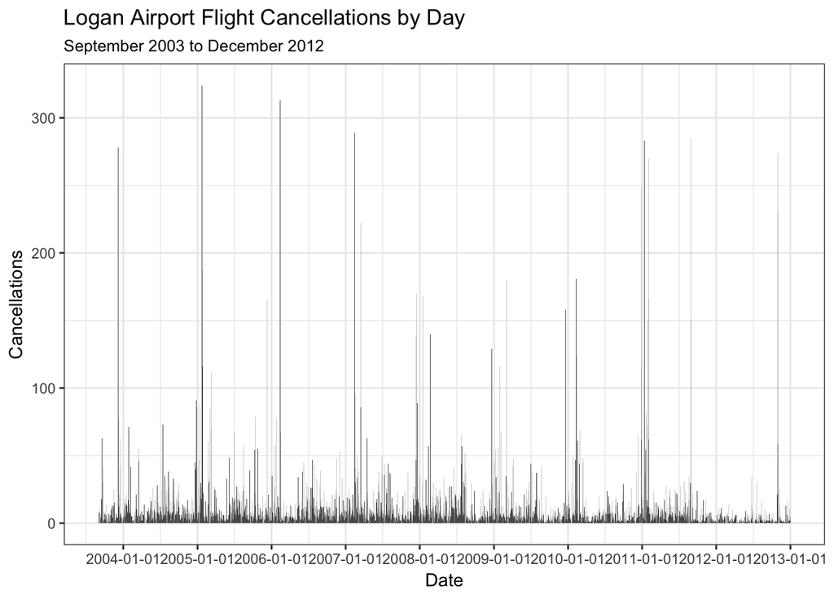

We partition our data into three subsets. The first, the training set, contains data from 2003-2009. The second, what we call the test set and what should technically be called the validation set, contains flights from 2010-2011. We call the third subset the “secret test set” (this should be called the test set). This contains the flights in 2012.

We use the first two subsets to train our model and prevent overfitting. We first train our model on the training set, and then look at how it performs in the test set. If we see that the model performs substantially better on the training set than on the test set, we will know that our model is overfitting and picking up trends in the training set that do not exist in the test set. We break these sets up by date because this allows us to “get into a time machine” to the end of the training set and imagine that we have all the data up to that date and want to predict flights after that date. An important assumption that we make in order to break the data up by date is that there is no structural change in how or why flights are cancelled in Boston that happens near the date of the split. After selecting a model that we think fits the data using the training and test sets, we peek at the “secret test set”. Our performance on the “secret test set” gives us an idea of how we really do out of sample, and what our model’s performance would be if we wanted to predict cancellations tomorrow.

While we are using all the flights we have from 2003 through 2009 as our training set, this data has over 700,000 entries and thus it is computationally expensive to train on such a large data set. We believe that we should be able to effectively train a model and understand its performing as long as we use at least 10,000 randomly selected entries from this training set. The training set we use to tune our model is actually only 2% of our total training data, which equates to roughly 15,000 entries.

# Basic Logistic Model

We began creating our model using basic logistic regression to classify a given flight as either cancelled (1) or not cancelled (0) using the amount of precipitation on that day (in inches).

**Basic Logistic Regression**

|  | *Dependent variable:* |
| --- | --- |
|  | Cancelled |
| PRCP | 0.831*** (0.108) |
| Constant | -3.569*** (0.071) |
| Observations | 7,862 |
| Log Likelihood | -1,086.161 |
| Akaike Inf. Crit. | 2,176.322 |
| *Note:* | p<0.1; p<0.05; p<0.01 |

We started by using the amount of precipitation in Boston on the day the flight occured as our predictor variable. Although we see that precipitation has a statistically signifcant relationship with the log odds of a flight being cancelled, when we look at the predictions of flight cancellations its clear that precipitation performs no better than just guessing that no flights will be cancelled because so few flights are cancelled.

Basic Logistic Regression Test Set Confusion Matrix

|  | No Cancellation | Cancellation |
| --- | --- | --- |
| Predicted No Cancellation | 216482 | 6689 |
| Predicted Cancellation | 0 | 0 |

This model simply guesses that no flights will be cancelled because only 3% of flights in our dataset are cancelled. We can therefore say that this model is 97% accurate because it correctly predicts the results for 97% of the flights. However this model does not add to our understanding of flight cancellations.

## Taking a Step Back: Cohen’s Kappa

Model Accuracy of 97% would be impressive if we could not also achieve this level of accuracy by guessing that no flights will be cancelled at all. A better metric we can use to evaluate models is Cohen’s Kappa, which measures the amount of information added by the model. Cohen’s Kappa quantifies how much of the gap between random guessing and perfect prediction we have made up with our model and can be calculated using the equation below.

$$Kappa = \frac{P_O - P_E}{1 - P_E}\\
P_O = P(\text{Agreement Observed}) \\
P_E = P(\text{Agreement Expected Due to Chance})$$

Cohen’s Kappa tells us how much better we are doing than randomly permuting our classifications and thus we want this number to be higher. It is bounded above by 1 which would mean we are predicting perfectly. A Kappa of 0 is equivalent to random permutations. Although Kappa is not bounded below by 0, values below zero mean that we are performing worse than random guessing which is very bad.

## Multivariable Logistic Regression Model

We then try another logistic regression, this time with more variables.

**Multivariable Logistic Regression**

|  | *Dependent variable:* |
| --- | --- |
|  | Cancelled |
| factor(MONTH)10 | -0.724 (0.456) |
| factor(MONTH)11 | -0.744* (0.424) |
| factor(MONTH)12 | -0.091 (0.303) |
| factor(MONTH)2 | -0.309 (0.324) |
| factor(MONTH)3 | -0.274 (0.321) |
| factor(MONTH)4 | 0.062 (0.382) |
| factor(MONTH)5 | -0.569 (0.491) |
| factor(MONTH)6 | -0.125 (0.550) |
| factor(MONTH)7 | -0.092 (0.589) |
| factor(MONTH)8 | -0.295 (0.590) |
| factor(MONTH)9 | -0.213 (0.523) |
| factor(DAY_OF_WEEK)2 | -0.185 (0.264) |
| factor(DAY_OF_WEEK)3 | 0.277 (0.239) |
| factor(DAY_OF_WEEK)4 | -0.079 (0.262) |
| factor(DAY_OF_WEEK)5 | -0.122 (0.262) |
| factor(DAY_OF_WEEK)6 | -0.360 (0.302) |
| factor(DAY_OF_WEEK)7 | -0.137 (0.267) |
| DISTANCE | -0.001*** (0.0001) |
| TMAX | -0.011 (0.016) |
| TMIN | 0.042* (0.023) |
| PRCP | 0.568*** (0.163) |
| SNOW | 0.337*** (0.038) |
| WESD |  |
| TMAX.atl | 0.021 (0.014) |
| TMIN.atl | -0.002 (0.015) |
| PRCP.atl | 0.131 (0.166) |
| WESD.atl |  |
| TMAX.nyc | 0.011 (0.018) |
| TMIN.nyc | -0.052** (0.026) |
| PRCP.nyc | 0.297** (0.125) |
| WESD.nyc |  |
| TMAX.det | -0.009 (0.013) |
| TMIN.det | -0.0004 (0.017) |
| PRCP.det | 0.623** (0.265) |
| WESD.det |  |
| Constant | -3.384*** (0.612) |
| Observations | 7,864 |
| Log Likelihood | -906.371 |
| Akaike Inf. Crit. | 1,876.743 |
| *Note:* | p<0.1; p<0.05; p<0.01 |

Now to calculate Cohen’s Kappa we can use the `fmsb::Kappa.test()` function on a confusion matrix of our predictions vs. the truth about each cancellation.

Multivariable Logistic Regression Test Set Confusion Matrix

|  | No Cancellation | Cancellation |
| --- | --- | --- |
| Predicted No Cancellation | 216295 | 6240 |
| Predicted Cancellation | 187 | 449 |

Multivariable Logistic Regression Kappa Values

| Training Kappa | Test Kappa |
| --- | --- |
| 0.1039101 | 0.1180033 |

## Single Variable LogitBoost Model

We can improve this prediction by using the Boosted algorithm LogitBoost from the `caret` package, which allows us to bootstrap our model through resampled data. In each iteration, the data is sampled, with harder to predict observations given larger sample weights. Then a logistic model is fit to the bootstrapped data. Once models have been fit to every bootstrapped sample, they are all averaged, weighted according to their performance on the training data.

Another aspect of LogitBoost is its use of decision stumps. This differs from a linear model, where a standard logistic model creates a linear relationship between log odds and inputs, LogitBoost creates a threshold for each predictor variable and uses this as a binary cutoff for prediction of our binary predicted variable. For example LogitBoost could create a threshold for distance on iteration 1 with a threshold of 500 where any flight with a distance of over 500 and any flight with a distance less than 500 is predicted as not cancelled. A logistic model assumes the same difference in log odds for going from 0 mile to 100 miles as going from 900 to 1000 miles which could have larger implications regarding fuel and plane size. These stumps allow us to capture large trends in the data with a single cutoff. A simple use of this algorithm is shown below.

```r
# print(Sys.time())
alex <- train(factor(CANCELLED) ~ PRCP,
              method = "LogitBoost",
              metric = "Kappa",
              data = small.training.set)
```

Single Variable LogitBoost Results

| nIter | Accuracy | Kappa | AccuracySD | KappaSD |
| --- | --- | --- | --- | --- |
| 11 | 0.9707229 | -8.01e-05 | 0.002431 | 0.0004006 |
| 21 | 0.9707229 | -8.01e-05 | 0.002431 | 0.0004006 |
| 31 | 0.9707229 | -8.01e-05 | 0.002431 | 0.0004006 |

Single Variable LogitBoost Decision Stumps

| feature | threshhold | sign |
| --- | --- | --- |
| 1 | 4.29 | -1 |
| 1 | 4.29 | -1 |
| 1 | 4.29 | -1 |
| 1 | 4.29 | -1 |
| 1 | 4.29 | -1 |
| 1 | 4.29 | -1 |
| 1 | 4.29 | -1 |
| 1 | 4.29 | -1 |
| 1 | 4.29 | -1 |
| 1 | 4.29 | -1 |
| 1 | 4.29 | -1 |

Here, with only one feature, the model uses this feature in each iteration with threshold 4.29 with a sign of -1. This means that if precipitation is below 4.29 on the day that the flight occurred each iteration of the model will “vote” that the flight is not cancelled.

Single Variable LogitBoost Test Set Confusion Matrix

|  | No Cancellation | Cancellation |
| --- | --- | --- |
| Predicted No Cancellation | 216482 | 6689 |
| Predicted Cancellation | 0 | 0 |

Single Variable LogitBoost Regression Kappa Values

| Training Kappa | Test Kappa |
| --- | --- |
| 0 | 0 |

Here test Kappa is again zero for this basic model but we believe it will improve greatly with more predictor variables.

## Multivariable LogitBoost Model

A more complex model:

```r
alex <- train(factor(CANCELLED) ~ factor(MONTH) + factor(DAY_OF_WEEK) + DISTANCE +
                TMAX + TMIN + WT01 + WT03 + SNOW + PRCP + AWND + WESD +
                TMAX.atl + TMIN.atl + WT01.atl + WT03.atl + PRCP.atl + AWND.atl + WESD.atl +
                TMAX.det + TMIN.det + WT01.det + WT03.det + PRCP.det + WESD.det +
                TMAX.nyc + TMIN.nyc + WT01.nyc + WT03.nyc + PRCP.nyc + WESD.nyc +
                TMAX_lag1 + TMIN_lag1 + SNOW_lag1 + PRCP_lag1 +
                TMAX_lag1.atl + TMIN_lag1.atl + PRCP_lag1.atl +
                TMAX_lag1.nyc + TMIN_lag1.nyc + PRCP_lag1.nyc +
                PRCP_lag1.det,
              method = "LogitBoost",
              metric = "Kappa",
              data = small.training.set)
```

Multivariable LogitBoost Results

| nIter | Accuracy | Kappa | AccuracySD | KappaSD |
| --- | --- | --- | --- | --- |
| 11 | 0.9702365 | 0.1105587 | 0.0028540 | 0.0592663 |
| 21 | 0.9701252 | 0.1105158 | 0.0022941 | 0.0486474 |
| 31 | 0.9691482 | 0.1188017 | 0.0026105 | 0.0525568 |

Multivariable LogitBoost Decision Stumps

| feature | threshhold | sign | Name |
| --- | --- | --- | --- |
| 23 | 9.30 | -1 | SNOW |
| 48 | 10.10 | -1 | SNOW_lag1 |
| 23 | 1.40 | -1 | SNOW |
| 24 | 0.48 | -1 | PRCP |
| 18 | 396.00 | 1 | DISTANCE |
| 28 | 72.00 | -1 | TMIN.atl |
| 35 | 72.00 | 1 | TMIN.det |
| 18 | 396.00 | -1 | DISTANCE |
| 20 | 15.00 | 1 | TMIN |
| 18 | 867.00 | 1 | DISTANCE |
| 31 | 0.20 | -1 | PRCP.atl |
| 20 | 14.00 | -1 | TMIN |
| 40 | 29.00 | 1 | TMAX.nyc |
| 31 | 0.15 | 1 | PRCP.atl |
| 18 | 861.00 | -1 | DISTANCE |
| 19 | 34.00 | -1 | TMAX |
| 18 | 280.00 | 1 | DISTANCE |
| 19 | 39.00 | 1 | TMAX |
| 34 | 36.00 | -1 | TMAX.det |
| 41 | 25.00 | 1 | TMIN.nyc |
| 51 | 35.00 | -1 | TMIN_lag1.atl |
| 50 | 43.00 | 1 | TMAX_lag1.atl |
| 28 | 72.00 | 1 | TMIN.atl |
| 27 | 87.00 | -1 | TMAX.atl |
| 50 | 84.00 | 1 | TMAX_lag1.atl |
| 51 | 69.00 | -1 | TMIN_lag1.atl |
| 47 | 59.00 | 1 | TMIN_lag1 |
| 46 | 80.00 | -1 | TMAX_lag1 |
| 51 | 69.00 | 1 | TMIN_lag1.atl |
| 50 | 84.00 | -1 | TMAX_lag1.atl |
| 27 | 87.00 | 1 | TMAX.atl |

Multivariable LogitBoost Test Set Confusion Matrix

|  | No Cancellation | Cancellation |
| --- | --- | --- |
| Predicted No Cancellation | 215680 | 5830 |
| Predicted Cancellation | 802 | 859 |

Multivariable LogitBoost Kappa Values

| Training Kappa | Test Kappa |
| --- | --- |
| 0.1767632 | 0.1961632 |

One large issue that we ran into is demonstrated here; the model repeatedly picks up on “DISTANCE” as an important variable. LogitBoost repeatedly makes thresholds around 860 but the sign associated with each is flip-flops. We can interpret this as “DISTANCE” being a good predictor in each iteration but not a very good predictor overall, as the signs for identical thresholds are inconsistent. This suggests that we should perhaps remove “DISTANCE” from the model because the algorithm is spending a lot of iterations focusing on “DISTANCE” with little to nothing show for it and could probably improve by focusing on other variables.

```r
#REMOVED DISTANCE
alex <- train(factor(CANCELLED) ~ factor(MONTH) + factor(DAY_OF_WEEK) +
                TMAX + TMIN + WT01 + WT03 + SNOW + PRCP + AWND + WESD +
                TMAX.atl + TMIN.atl + WT01.atl + WT03.atl + PRCP.atl + AWND.atl + WESD.atl +
                TMAX.det + TMIN.det + WT01.det + WT03.det + PRCP.det + WESD.det +
                TMAX.nyc + TMIN.nyc + WT01.nyc + WT03.nyc + PRCP.nyc + WESD.nyc +
                TMAX_lag1 + TMIN_lag1 + SNOW_lag1 + PRCP_lag1 +
                TMAX_lag1.atl + TMIN_lag1.atl + PRCP_lag1.atl +
                TMAX_lag1.nyc + TMIN_lag1.nyc + PRCP_lag1.nyc +
                PRCP_lag1.det,
              method = "LogitBoost",
              metric = "Kappa",
              data = small.training.set)
```

Multivariable LogitBoost Results

| nIter | Accuracy | Kappa | AccuracySD | KappaSD |
| --- | --- | --- | --- | --- |
| 11 | 0.9708581 | 0.1376031 | 0.0027124 | 0.0437424 |
| 21 | 0.9698369 | 0.1477808 | 0.0028434 | 0.0399278 |
| 31 | 0.9688102 | 0.1313754 | 0.0028228 | 0.0515281 |

Multivariable LogitBoost Decision Stumps

| feature | threshhold | sign | Name |
| --- | --- | --- | --- |
| 22 | 9.30 | -1 | SNOW |
| 47 | 10.10 | -1 | SNOW_lag1 |
| 22 | 1.40 | -1 | SNOW |
| 23 | 0.48 | -1 | PRCP |
| 13 | 0.00 | -1 | factor(DAY_OF_WEEK)3 |
| 23 | 0.45 | 1 | PRCP |
| 13 | 0.00 | 1 | factor(DAY_OF_WEEK)3 |
| 23 | 0.48 | -1 | PRCP |
| 13 | 0.00 | -1 | factor(DAY_OF_WEEK)3 |
| 23 | 0.45 | 1 | PRCP |
| 13 | 0.00 | 1 | factor(DAY_OF_WEEK)3 |
| 23 | 0.48 | -1 | PRCP |
| 13 | 0.00 | -1 | factor(DAY_OF_WEEK)3 |
| 23 | 0.45 | 1 | PRCP |
| 13 | 0.00 | 1 | factor(DAY_OF_WEEK)3 |
| 23 | 0.48 | -1 | PRCP |
| 13 | 0.00 | -1 | factor(DAY_OF_WEEK)3 |
| 23 | 0.45 | 1 | PRCP |
| 13 | 0.00 | 1 | factor(DAY_OF_WEEK)3 |
| 23 | 0.48 | -1 | PRCP |
| 13 | 0.00 | -1 | factor(DAY_OF_WEEK)3 |

Multivariable LogitBoost Test Set Confusion Matrix

|  | No Cancellation | Cancellation |
| --- | --- | --- |
| Predicted No Cancellation | 216254 | 6020 |
| Predicted Cancellation | 228 | 669 |

Multivariable LogitBoost Kappa Values

| Training Kappa | Test Kappa |
| --- | --- |
| 0.1513603 | 0.1704979 |

```r
#REMOVED TMIN and ADDED TMIN.l32 and TMAX.l32
alex <- train(factor(CANCELLED) ~ factor(MONTH) + factor(DAY_OF_WEEK) +
                TMAX + WT01 + WT03 + SNOW + PRCP + AWND + WESD + PRCP*PRCP.TMIN.l32 + PRCP*PRCP.TMAX.l32 +
                TMAX.atl + TMIN.atl + WT01.atl + WT03.atl + PRCP.atl + WESD.atl +
                TMAX.det + TMIN.det + WT01.det + WT03.det + PRCP.det + WESD.det +
                TMAX.nyc + TMIN.nyc + WT01.nyc + WT03.nyc + PRCP.nyc + WESD.nyc +
                TMAX_lag1 + TMIN_lag1 + SNOW_lag1 + PRCP_lag1 +
                TMAX_lag1.atl + TMIN_lag1.atl + PRCP_lag1.atl +
                TMAX_lag1.nyc + TMIN_lag1.nyc + PRCP_lag1.nyc +
                PRCP_lag1.det,
              method = "LogitBoost",
              metric = "Kappa",
              data = small.training.set)
```

Multivariable LogitBoost Results

| nIter | Accuracy | Kappa | AccuracySD | KappaSD |
| --- | --- | --- | --- | --- |
| 11 | 0.9721432 | 0.1377213 | 0.0028512 | 0.0456468 |
| 21 | 0.9717657 | 0.1384734 | 0.0030160 | 0.0442195 |
| 31 | 0.9707716 | 0.1301100 | 0.0029545 | 0.0406980 |

Multivariable LogitBoost Decision Stumps

| feature | threshhold | sign | Name |
| --- | --- | --- | --- |
| 21 | 9.30 | -1 | SNOW |
| 26 | 0.50 | -1 | PRCP.TMAX.l32 |
| 25 | 0.39 | -1 | PRCP.TMIN.l32 |
| 43 | 1.79 | -1 | PRCP.nyc |
| 41 | 0.00 | -1 | WT01.nyc |
| 43 | 0.01 | 1 | PRCP.nyc |
| 23 | 13.42 | -1 | AWND |
| 43 | 0.01 | -1 | PRCP.nyc |
| 23 | 12.75 | 1 | AWND |
| 41 | 0.00 | 1 | WT01.nyc |
| 43 | 1.61 | 1 | PRCP.nyc |
| 22 | 0.92 | -1 | PRCP |
| 49 | 59.00 | -1 | TMAX_lag1.atl |
| 39 | 39.00 | 1 | TMAX.nyc |
| 22 | 0.85 | 1 | PRCP |
| 43 | 0.58 | -1 | PRCP.nyc |
| 48 | 0.06 | -1 | PRCP_lag1 |
| 54 | 0.02 | 1 | PRCP_lag1.nyc |
| 23 | 11.63 | -1 | AWND |
| 37 | 0.38 | -1 | PRCP.det |
| 48 | 0.29 | 1 | PRCP_lag1 |

Multivariable LogitBoost Test Set Confusion Matrix

|  | No Cancellation | Cancellation |
| --- | --- | --- |
| Predicted No Cancellation | 215319 | 5984 |
| Predicted Cancellation | 1163 | 705 |

Multivariable LogitBoost Kappa Values

| Training Kappa | Test Kappa |
| --- | --- |
| 0.1503126 | 0.1537027 |

For similar reasons we now remove PRCP, PRCP.TMIN.l32, TMAX.nyc, TMAX, WT03, MONTH, PRCP.nyc, TMIN_lag1.atl, WT01, WT01.nyc, PRCP.

```r
#REMOVED PRCP
#PRCP.TMIN.l32
#TMAX.nyc
#TMAX
#WT03
#MONTH
#PRCP.nyc
#TMIN_lag1.atl
#WT01 & WT01.nyc & PRCP
alex <- train(factor(CANCELLED) ~ factor(DAY_OF_WEEK) +
                SNOW + AWND + WESD + PRCP.TMAX.l32 +
                TMAX.atl + TMIN.atl + WT01.atl + WT03.atl + PRCP.atl + AWND.atl + WESD.atl +
                TMAX.det + TMIN.det + WT01.det + WT03.det + PRCP.det + WESD.det +
                TMIN.nyc + WT03.nyc + WESD.nyc +
                TMAX_lag1 + TMIN_lag1 + SNOW_lag1 + PRCP_lag1 +
                TMAX_lag1.atl + PRCP_lag1.atl +
                TMAX_lag1.nyc + TMIN_lag1.nyc + PRCP_lag1.nyc +
                PRCP_lag1.det,
              method = "LogitBoost",
              metric = "Kappa",
              data = small.training.set)
```

Multivariable LogitBoost Results

| nIter | Accuracy | Kappa | AccuracySD | KappaSD |
| --- | --- | --- | --- | --- |
| 11 | 0.9717738 | 0.0991022 | 0.0026503 | 0.0447009 |
| 21 | 0.9713036 | 0.1126160 | 0.0027291 | 0.0514579 |
| 31 | 0.9707640 | 0.1192017 | 0.0032053 | 0.0459019 |

Multivariable LogitBoost Decision Stumps

| feature | threshhold | sign | Name |
| --- | --- | --- | --- |
| 7 | 9.30 | -1 | SNOW |
| 10 | 0.50 | -1 | PRCP.TMAX.l32 |
| 7 | 1.40 | -1 | SNOW |
| 34 | 79.00 | -1 | TMIN_lag1.nyc |
| 16 | 5.37 | -1 | AWND.atl |
| 12 | 73.00 | -1 | TMIN.atl |
| 18 | 78.00 | 1 | TMAX.det |
| 19 | 61.00 | -1 | TMIN.det |
| 18 | 68.00 | 1 | TMAX.det |
| 19 | 52.00 | -1 | TMIN.det |
| 34 | 58.00 | 1 | TMIN_lag1.nyc |
| 33 | 76.00 | -1 | TMAX_lag1.nyc |
| 27 | 72.00 | 1 | TMAX_lag1 |
| 28 | 56.00 | -1 | TMIN_lag1 |
| 19 | 52.00 | 1 | TMIN.det |
| 27 | 72.00 | -1 | TMAX_lag1 |
| 33 | 80.00 | 1 | TMAX_lag1.nyc |
| 27 | 80.00 | -1 | TMAX_lag1 |
| 28 | 62.00 | 1 | TMIN_lag1 |
| 16 | 5.37 | 1 | AWND.atl |
| 31 | 58.00 | -1 | TMAX_lag1.atl |
| 34 | 26.00 | 1 | TMIN_lag1.nyc |
| 28 | 20.00 | -1 | TMIN_lag1 |
| 31 | 58.00 | 1 | TMAX_lag1.atl |
| 34 | 30.00 | -1 | TMIN_lag1.nyc |
| 28 | 21.00 | 1 | TMIN_lag1 |
| 16 | 5.14 | -1 | AWND.atl |
| 28 | 64.00 | -1 | TMIN_lag1 |
| 27 | 75.00 | 1 | TMAX_lag1 |
| 18 | 68.00 | -1 | TMAX.det |
| 33 | 67.00 | 1 | TMAX_lag1.nyc |

Multivariable LogitBoost Test Set Confusion Matrix

|  | No Cancellation | Cancellation |
| --- | --- | --- |
| Predicted No Cancellation | 214699 | 5985 |
| Predicted Cancellation | 1783 | 704 |

Multivariable LogitBoost Kappa Values

| Training Kappa | Test Kappa |
| --- | --- |
| 0.1179037 | 0.1394625 |

At this point this algorithm continues to cycle thorough variables and we will end up removing ones that are rather intuitive for the prediction of flight cancellations such as snow and precipitation. Additionally, this technique does not seem to help, as each time we remove variables our Kappa decreases. To make sense of these cycles we would have to look at interactions between multiple variables. For example, we would need to look at the amount of precipitation when the temperature was below freezing because we expect that this precipitation would better predict a cancellation than rain would.

## Introducing Random Forests

To account for these interactions between variables we transitioned to using random forests. Where LogitBoost makes one threshold per iteration, a random forest makes multiple thresholds that each factor into its predictions and does not re-weight observations for resampling between iterations. These multiple thresholds will account for the interactions between variables although resampling will remove emphasis on correctly predicting observations that are hard to predict.

```r
# alex <- train(factor(CANCELLED) ~ factor(MONTH) + factor(DAY_OF_WEEK) + DISTANCE +
#                 TMAX + TMIN + WT01 + WT03 + SNOW + PRCP + AWND + WESD +
#                 TMAX.atl + TMIN.atl + WT01.atl + WT03.atl + PRCP.atl + AWND.atl + WESD.atl +
#                 TMAX.det + TMIN.det + WT01.det + WT03.det + PRCP.det + WESD.det +
#                 TMAX.nyc + TMIN.nyc + WT01.nyc + WT03.nyc + PRCP.nyc + WESD.nyc +
#                 TMAX_lag1 + TMIN_lag1 + SNOW_lag1 + PRCP_lag1 +
#                 TMAX_lag1.atl + TMIN_lag1.atl + PRCP_lag1.atl +
#                 TMAX_lag1.nyc + TMIN_lag1.nyc + PRCP_lag1.nyc +
#                 PRCP_lag1.det,
#               method = "rf",
#               metric = "Kappa",
#               data = sample_frac(small.training.set, 1))
```

Random Forest Results

| mtry | Accuracy | Kappa | AccuracySD | KappaSD |
| --- | --- | --- | --- | --- |
| 2 | 0.9684172 | 0.0952350 | 0.0028162 | 0.0357198 |
| 29 | 0.9589170 | 0.1339602 | 0.0024059 | 0.0366265 |
| 56 | 0.9577328 | 0.1424338 | 0.0024454 | 0.0347015 |

Random Forest Test Set Confusion Matrix

|  | No Cancellation | Cancellation |
| --- | --- | --- |
| Predicted No Cancellation | 215456 | 5857 |
| Predicted Cancellation | 1026 | 832 |

Random Forest Kappa Values

| Training Kappa | Test Kappa |
| --- | --- |
| 0.9159781 | 0.1840554 |

# Revisiting Previous Models

One way that we can attempt to get a better idea of whether or not a flight will be cancelled from these models is re-evaluating our cutoff for predicted probabilities. In our original logistic models we used a cutoff of 0.5, meaning that if P(cancellation) > 0.5 we classify the flight as cancelled and if P(cancellation < 0.5) we classify the flight as not cancelled. If our model has spikes in predicted probability for flights that are cancelled we can capture this through a new cutoff. This is computationally inexpensive and intuitive that our model would have a hard time predicting P(cancellation) > 0.5 because so few flights are actually cancelled. We try different cutoffs and look at the Kappa values that these new cutoffs give us below.

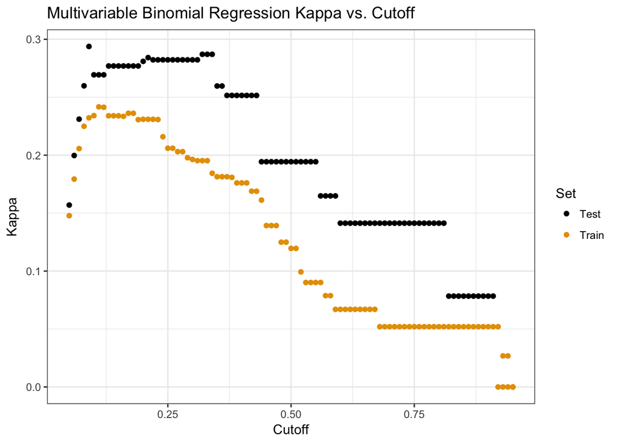

This figure shows the Kappa value at different cutoffs for our Multivariable Logistic Regression model. We see that the cutoffs that give us the highest Kappa values are not at 0.5, but between 0.1 and 0.2.

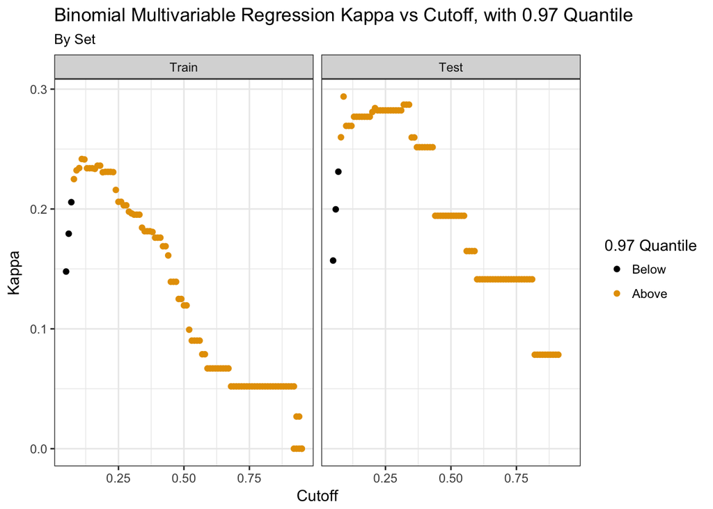

Here the Kappa values for both the test and training sets are shown with various cutoffs. We can see that where we go from above the 0.97 quantile to below the 0.97 quantile of predicted probabilities seems to be the cutoff in that it achieves the highest Kappa.

## An Estimator

To estimate the optimal cutoff for our random forest we would ideally run a random forest on the entire training set and then look at each cutoff and find the optimal choice. However, this is computationally expensive so instead we trained a random forest on 288 random selections on one thousandth of our dataset (roughly 1000 observations) selected randomly. This is a small sample size and is likely not as representative of the true values as we would like, but we were limited to this size by run time. At each iteration we trained the model and then determined the optimal cutoff.

We estimated the optimal cutoff as the top 3% of predicted probabilities. To determine whether or not this estimator is biased we looked at the the difference between the estimated cutoff and the true optimal cutoff for each iteration.

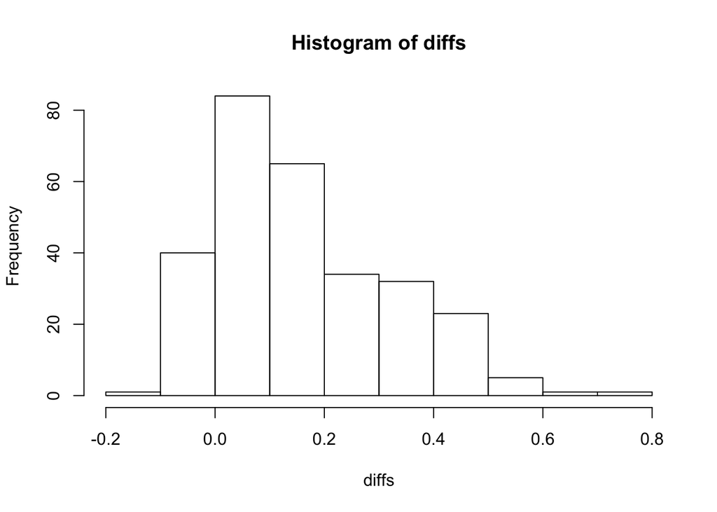

Above is a histogram of the differences between the estimated and optimal cutoffs. We do not believe that this data is normally distributed, therefore to test whether or not the true difference could be 0 we must bootstrap.

Null Hypothesis: The true mean of the difference between the optimal cutoff and our estimated cutoff is 0. Alternative Hypothesis: The true mean of the difference between the optimal cutoff and our estimated cutoff is not 0.

```
## [1] 0.1639013
```

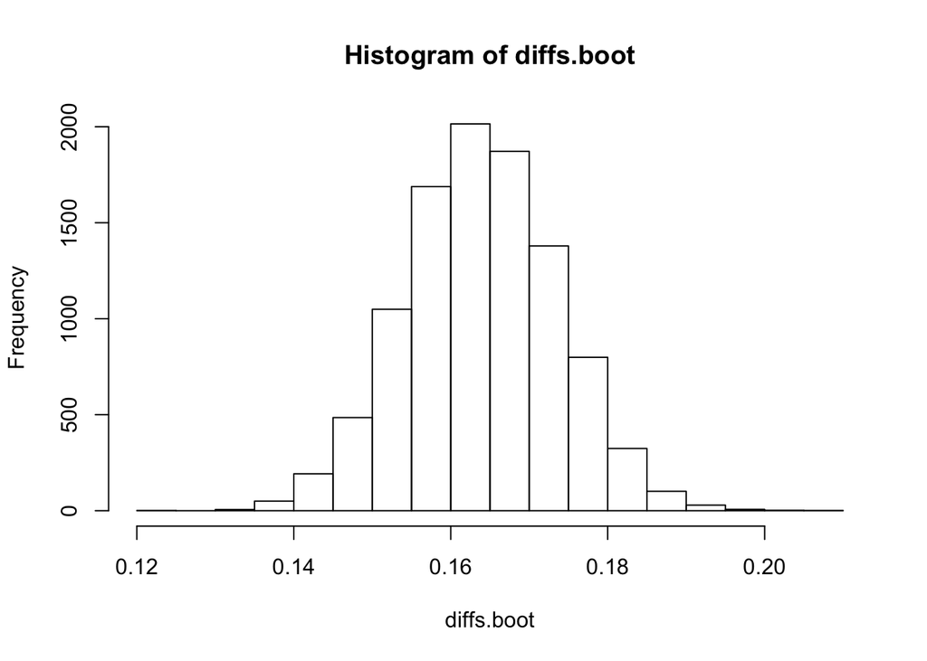

```
## [1] 0
```

Here 0% of our boostrapped values for the difference between the estimated and optimal cutoffs are below 0 so therefore there is aproximately a 0% chance that the true difference between the estimator and the true value is 0 assuming that these data are representative which we believe they are because N is large. Therefore we conclude that this estimator is biased by rejecting the null hypothesis.

To calculate its bias we can calculate the expected (mean) distance between the estimator and the true optimal cutoff.

```
## [1] -0.03113903
```

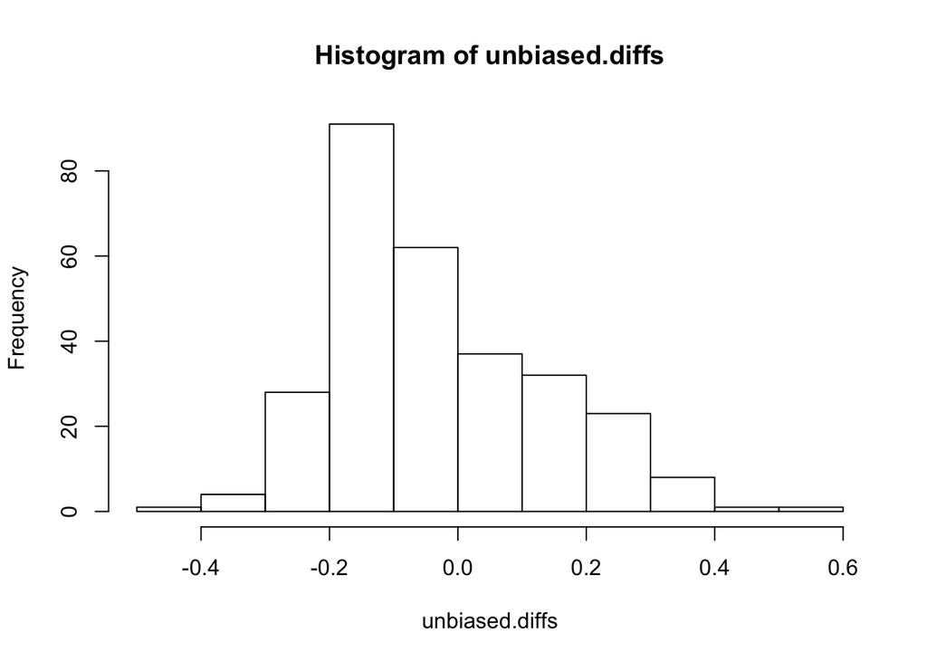

```
## [1] 0.164021
```

We can therefore conclude that an unbiased estimator for the true optimal cutoff of a random forest trained on our training set to predict on our test set is the 97% quantile of the predicted probabilities - 0.164021.

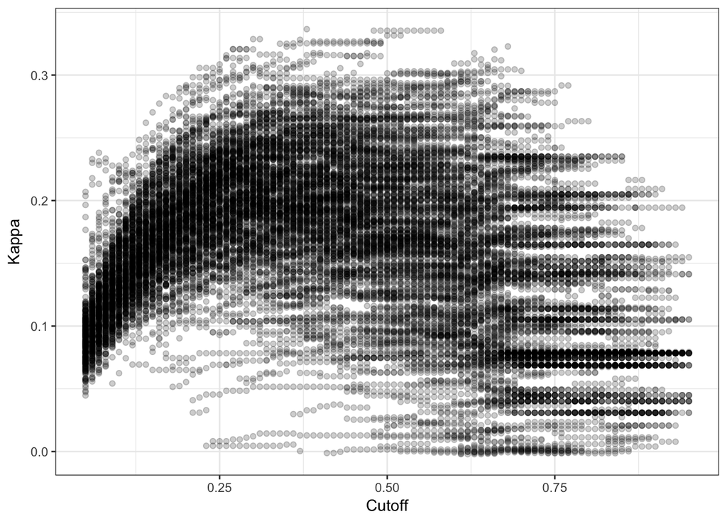

## A New Multivariable Logistic Regression Model

We can make an improved Multivariable Logistic Regression model by changing the cutoff to 0.11. This model is shown below.

**New Multivariable Logistic Regression**

|  | *Dependent variable:* |
| --- | --- |
|  | Cancelled |
| factor(MONTH)10 | -0.724 (0.456) |
| factor(MONTH)11 | -0.744* (0.424) |
| factor(MONTH)12 | -0.091 (0.303) |
| factor(MONTH)2 | -0.309 (0.324) |
| factor(MONTH)3 | -0.274 (0.321) |
| factor(MONTH)4 | 0.062 (0.382) |
| factor(MONTH)5 | -0.569 (0.491) |
| factor(MONTH)6 | -0.125 (0.550) |
| factor(MONTH)7 | -0.092 (0.589) |
| factor(MONTH)8 | -0.295 (0.590) |
| factor(MONTH)9 | -0.213 (0.523) |
| factor(DAY_OF_WEEK)2 | -0.185 (0.264) |
| factor(DAY_OF_WEEK)3 | 0.277 (0.239) |
| factor(DAY_OF_WEEK)4 | -0.079 (0.262) |
| factor(DAY_OF_WEEK)5 | -0.122 (0.262) |
| factor(DAY_OF_WEEK)6 | -0.360 (0.302) |
| factor(DAY_OF_WEEK)7 | -0.137 (0.267) |
| DISTANCE | -0.001*** (0.0001) |
| TMAX | -0.011 (0.016) |
| TMIN | 0.042* (0.023) |
| PRCP | 0.568*** (0.163) |
| SNOW | 0.337*** (0.038) |
| WESD |  |
| TMAX.atl | 0.021 (0.014) |
| TMIN.atl | -0.002 (0.015) |
| PRCP.atl | 0.131 (0.166) |
| WESD.atl |  |
| TMAX.nyc | 0.011 (0.018) |
| TMIN.nyc | -0.052** (0.026) |
| PRCP.nyc | 0.297** (0.125) |
| WESD.nyc |  |
| TMAX.det | -0.009 (0.013) |
| TMIN.det | -0.0004 (0.017) |
| PRCP.det | 0.623** (0.265) |
| WESD.det |  |
| Constant | -3.384*** (0.612) |
| Observations | 7,864 |
| Log Likelihood | -906.371 |
| Akaike Inf. Crit. | 1,876.743 |
| *Note:* | p<0.1; p<0.05; p<0.01 |

New Multivariable Logistic Regression Test Set Confusion Matrix

|  | No Cancellation | Cancellation |
| --- | --- | --- |
| Predicted No Cancellation | 211395 | 4766 |
| Predicted Cancellation | 5087 | 1923 |

New Multivariable Logistic Regression Kappa Value

| Training Kappa | Test Kappa |
| --- | --- |
| 0.2011159 | 0.2579893 |

## A New Random Forest Model

Similarly, we can make a new Random Forest model using this unbiased estimator. Here we use our model to predict on the training set and then calculate the 97% quantile of the predicted probabilities and unbias it by subtracting the bias we calculated earlier (0.164021)

Multivariable Random Forest Results

| mtry | Accuracy | Kappa | AccuracySD | KappaSD |
| --- | --- | --- | --- | --- |
| 2 | 0.9684172 | 0.0952350 | 0.0028162 | 0.0357198 |
| 29 | 0.9589170 | 0.1339602 | 0.0024059 | 0.0366265 |
| 56 | 0.9577328 | 0.1424338 | 0.0024454 | 0.0347015 |

Random Forest Test Set Confusion Matrix

|  | No Cancellation | Cancellation |
| --- | --- | --- |
| Predicted No Cancellation | 211998 | 5337 |
| Predicted Cancellation | 4484 | 1352 |

New Random Forest Kappa Values

| Training Kappa | Test Kappa |
| --- | --- |
| 0.915027 | 0.1933577 |

# Results: Our Best Model

The model that performed best on the test set was the New Multivariable Logistic Regression model with the changed cutoff. We will now run this model on the secret test set to see what true out of sample performance is like.

New Multivariable Logistic Regression Secret Test Set Confusion Matrix

|  | No Cancellation | Cancellation |
| --- | --- | --- |
| Predicted No Cancellation | 99061 | 1443 |
| Predicted Cancellation | 604 | 39 |

New Multivariable Logistic Regression Kappa Values

| Training Kappa | Test Kappa | Secret Test Kappa |
| --- | --- | --- |
| 0.2011159 | 0.2579893 | 0.0280879 |

This extremely low secret test Kappa value is surprising and suggests that we either started to overfit when we used the cutoff, or there is some structural change that happened in 2012 that caused flights from Logan to be delayed differently.

# Conclusion

In conclusion predicting flight cancellations is difficult. It is hard to predict these classifications because such an overwhelming majority of flights are not cancelled. This creates a strong trend in the data that is very hard to predict against and thus it is hard to correctly classify cancelled flights. Although we make use of Cohen’s Kappa, our model still struggles to predict against this trend even when using more advanced algorithms. It is also interesting that logistic regression outperforms both of our machine learning algorithms when given similar amounts of data even when we introduce random forests which should capture more of the relationships between variables. We can further conclude that there must be some sort of structural change to how flights are cancelled because our model performs well on the test set but not well at all on the secret test set even though it hasn’t seen either of these subsets of our data. Our model performs well on the test set (data from 2010-2011) but performs much worse on the secret test set (data from 2012) which none of our models were able to use. This shows that even though the model did not see either of these datasets when training, there must be some difference in the mechanism that determines whether a flight is cancelled from 2010/2011 to 2012 as our model does not seem to be overfit when looking at just the training and test sets. It could be interesting to look into what this structural change may have been as well as look in to cancellations at other airports and flight delay length.